# Biostat 203B Homework 4

Due Mar 18 @ 11:59PM

Load database libraries and the tidyverse frontend:

```r
suppressPackageStartupMessages(library(tidyverse))
suppressPackageStartupMessages(library(lubridate))
suppressPackageStartupMessages(library(miceRanger))
suppressPackageStartupMessages(library(caret))
suppressPackageStartupMessages(library(keras))
suppressPackageStartupMessages(library(tensorflow))
```

# 1 Q1. Missing data

Through the Shiny app developed in HW3, we observe abundant missing values in the MIMIC-IV ICU cohort we created. In this question, we use multiple imputation to obtain a data set without missing values.

0. Read following tutorials on the R package miceRanger for imputation: https://github.com/farrellday/miceRanger, https://cran.r-project.org/web/packages/miceRanger/vignettes/miceAlgorithm.html.

   A more thorough book treatment of the practical imputation strategies is the book [*Flexible Imputation of Missing Data*](https://stefvanbuuren.name/fimd/) by Stef van Buuren.
1. Explain the jargon MCAR, MAR, and MNAR.

## 1.1 Solution

- MCAR stands for “missing completely at rondom.” This means that the cause of missing data is unrelated to the data itself, so there are no systematic differences between observations with and without missing data. Therefore, no bias is introduced, but the statistical power will be lower.
- MAR stands for “missing at random.” This means that missing data is systematically different from the observed data, but this difference can be explained by other fully observed variables.
- MNAR stands for “missing not at random.” This means that missing data is systematically related to unobserved data that is not measured by the researcher.
2. Explain in a couple of sentences how the Multiple Imputation by Chained Equations (MICE) work.

## 1.2 Solution

- MICE is a multiple imputation method that replaces missing data under assumptions about the missingness mechanism (MCAR, MAR, or MNAR). MICE fits a separate regression model for each variable with missing data based on the other variables to predict missing values. In order to fit the regression model, temporary placeholders are imputed for all variables with missing data. When MICE reaches a variable, all of its placeholders are set back to missing when the regression is conducted to generate predicted values. This process is repeated for all imputed variables a specified number of times (i.e., number of cycles).
3. Perform a data quality check of the ICU stays data. Discard variables with substantial missingness, say >5000 `NA`s. Replace apparent data entry errors by `NA`s.

## 1.3 Solution

```r
# Load the Data
icu_cohort <- readRDS("../hw3/mimiciv_shiny/icu_cohort.rds")
# Check for substantial missingness
summary(icu_cohort)
```

```
##    subject_id          hadm_id           admittime
##  Min.   :10000032   Min.   :20000094   Min.   :2110-01-11 10:14:00
##  1st Qu.:12483898   1st Qu.:22478093   1st Qu.:2132-11-03 21:46:00
##  Median :14991424   Median :24947644   Median :2152-09-28 20:40:00
##  Mean   :14989837   Mean   :24975852   Mean   :2152-10-27 02:08:14
##  3rd Qu.:17495811   3rd Qu.:27477277   3rd Qu.:2172-11-04 12:57:00
##  Max.   :19999987   Max.   :29999828   Max.   :2211-05-01 06:57:00
##
##    dischtime                     deathtime                   admission_type
##  Min.   :2110-01-15 17:31:00   Min.   :2110-01-25 09:40:00   Length:53065
##  1st Qu.:2132-11-14 16:40:00   1st Qu.:2132-07-10 07:00:00   Class :character
##  Median :2152-10-07 17:00:00   Median :2152-02-27 00:01:00   Mode  :character
##  Mean   :2152-11-05 12:22:14   Mean   :2152-05-26 08:36:13
##  3rd Qu.:2172-11-10 14:55:00   3rd Qu.:2172-05-05 03:35:00
##  Max.   :2211-05-12 17:54:00   Max.   :2211-01-17 12:34:00
##                                NA's   :47558
##  admission_location discharge_location  insurance           language
##  Length:53065       Length:53065       Length:53065       Length:53065
##  Class :character   Class :character   Class :character   Class :character
##  Mode  :character   Mode  :character   Mode  :character   Mode  :character
##
##
##
##
##  marital_status      ethnicity           edregtime
##  Length:53065       Length:53065       Min.   :2110-01-11 21:42:00
##  Class :character   Class :character   1st Qu.:2133-09-04 07:54:45
##  Mode  :character   Mode  :character   Median :2153-05-30 21:13:00
##                                        Mean   :2153-07-13 01:51:15
##                                        3rd Qu.:2173-07-26 18:34:45
##                                        Max.   :2211-05-01 06:07:00
##                                        NA's   :19613
##    edouttime                   hospital_expire_flag
##  Min.   :2110-01-12 00:54:00   Min.   :0.0000
##  1st Qu.:2133-09-04 18:16:00   1st Qu.:0.0000
##  Median :2153-05-30 23:17:00   Median :0.0000
##  Mean   :2153-07-13 07:44:14   Mean   :0.1039
##  3rd Qu.:2173-07-26 21:44:00   3rd Qu.:0.0000
##  Max.   :2211-05-01 09:57:00   Max.   :1.0000
##  NA's   :19613
```

[output cut: 49 more lines]

```
##  Min.   :  0.00   Min.   :  0.00         Min.   :     0.00
##  1st Qu.: 15.00   1st Qu.: 97.60         1st Qu.:    70.00
##  Median : 18.00   Median : 98.10         Median :    81.00
##  Mean   : 18.69   Mean   : 98.03         Mean   :    87.43
##  3rd Qu.: 22.00   3rd Qu.: 98.70         3rd Qu.:    93.00
##  Max.   :180.00   Max.   :106.00         Max.   :140119.00
##  NA's   :62       NA's   :953            NA's   :704
##  non_invasive_blood_pressure_systolic   admit_age      thirty_day_mort
##  Min.   :    0.0                      Min.   : 19.00   Length:53065
##  1st Qu.:  106.0                      1st Qu.: 54.00   Class :character
##  Median :  122.0                      Median : 66.00   Mode  :character
##  Mean   :  123.8                      Mean   : 64.54
##  3rd Qu.:  139.0                      3rd Qu.: 78.00
##  Max.   :12262.0                      Max.   :102.00
##  NA's   :683
```

```r
# Discard deathtime, edregtime, edouttime, and dod (>5000 NAs)
icu_cohort <- select(icu_cohort, -c(deathtime, edregtime, edouttime, dod))
summary(icu_cohort)
```

```
##    subject_id          hadm_id           admittime
##  Min.   :10000032   Min.   :20000094   Min.   :2110-01-11 10:14:00
##  1st Qu.:12483898   1st Qu.:22478093   1st Qu.:2132-11-03 21:46:00
##  Median :14991424   Median :24947644   Median :2152-09-28 20:40:00
##  Mean   :14989837   Mean   :24975852   Mean   :2152-10-27 02:08:14
##  3rd Qu.:17495811   3rd Qu.:27477277   3rd Qu.:2172-11-04 12:57:00
##  Max.   :19999987   Max.   :29999828   Max.   :2211-05-01 06:57:00
##
##    dischtime                   admission_type     admission_location
##  Min.   :2110-01-15 17:31:00   Length:53065       Length:53065
##  1st Qu.:2132-11-14 16:40:00   Class :character   Class :character
##  Median :2152-10-07 17:00:00   Mode  :character   Mode  :character
##  Mean   :2152-11-05 12:22:14
##  3rd Qu.:2172-11-10 14:55:00
##  Max.   :2211-05-12 17:54:00
##
##  discharge_location  insurance           language         marital_status
##  Length:53065       Length:53065       Length:53065       Length:53065
##  Class :character   Class :character   Class :character   Class :character
##  Mode  :character   Mode  :character   Mode  :character   Mode  :character
##
##
##
##
##   ethnicity         hospital_expire_flag     intime
##  Length:53065       Min.   :0.0000       Min.   :2110-01-11 10:16:06
##  Class :character   1st Qu.:0.0000       1st Qu.:2132-11-05 21:29:00
##  Mode  :character   Median :0.0000       Median :2152-09-29 21:13:55
##                     Mean   :0.1039       Mean   :2152-10-28 03:05:41
##                     3rd Qu.:0.0000       3rd Qu.:2172-11-04 17:18:32
##                     Max.   :1.0000       Max.   :2211-05-01 06:59:19
##
##     stay_id         first_careunit     last_careunit
##  Min.   :30000153   Length:53065       Length:53065
##  1st Qu.:32467111   Class :character   Class :character
##  Median :34987214   Mode  :character   Mode  :character
##  Mean   :34984050
##  3rd Qu.:37487113
##  Max.   :39999810
##
```

[output cut: 41 more lines]

```
##  Min.   :     0.00                Min.   :    0.0
##  1st Qu.:    70.00                1st Qu.:  106.0
##  Median :    81.00                Median :  122.0
##  Mean   :    87.43                Mean   :  123.8
##  3rd Qu.:    93.00                3rd Qu.:  139.0
##  Max.   :140119.00                Max.   :12262.0
##  NA's   :704                      NA's   :683
##    admit_age      thirty_day_mort
##  Min.   : 19.00   Length:53065
##  1st Qu.: 54.00   Class :character
##  Median : 66.00   Mode  :character
##  Mean   : 64.54
##  3rd Qu.: 78.00
##  Max.   :102.00
##
```

```r
# Remove outliers using 1.5 IQR rule
for (i in 23:38) {
  col_vec <- icu_cohort[[i]]
  iqr <- IQR(col_vec, na.rm = TRUE)
  q1 <- quantile(col_vec, 0.25, na.rm = TRUE)
  q3 <- quantile(col_vec, 0.75, na.rm = TRUE)
  col_vec[col_vec > q3 + 1.5 * iqr] <- NA
  col_vec[col_vec < q1 - 1.5 * iqr] <- NA
  icu_cohort[[i]] <- col_vec
}
# Remove variables not used in Question 2
icu_cohort_final <- select(icu_cohort, -c(1:9, 12:18, 20:22))
icu_cohort_final %>%
  print(width = Inf)
```

```
## # A tibble: 53,065 × 20
##    marital_status ethnicity              gender   wbc sodium calcium glucose
##    <chr>          <chr>                  <chr>  <dbl>  <dbl>   <dbl>   <dbl>
##  1 MARRIED        OTHER                  M        7.8    130     8.2     113
##  2 SINGLE         OTHER                  F        3.5    141     8.1      99
##  3 WIDOWED        WHITE                  F       10.6    139     8.9      78
##  4 SINGLE         WHITE                  F       12.1    134     9.2     106
##  5 SINGLE         BLACK/AFRICAN AMERICAN M        5.4    143     8.4     127
##  6 DIVORCED       WHITE                  F        9.2    138     9.2     135
##  7 MARRIED        HISPANIC/LATINO        F        3.6    138     9        99
##  8 MARRIED        WHITE                  F       14.7    145     8.3     157
##  9 SINGLE         WHITE                  F        7.1    139     9.2      85
## 10 MARRIED        WHITE                  F       20.1    137     9.6      98
##    chloride magnesium potassium creatinine hematocrit bicarbonate heart_rate
##       <dbl>     <dbl>     <dbl>      <dbl>      <dbl>       <dbl>      <dbl>
```

[output cut: 35 more lines]

4. Impute missing values by `miceRanger` (request $m=3$ data sets). This step is computational intensive. Make sure to save the imputation results as a file. Hint: Setting `max.depth=10` in the `miceRanger` function may cut some computing time.

## 1.4 Solution

```r
mice <- miceRanger(
  data = icu_cohort_final,
  m = 3,
  max.depth = 10,
  returnModels = FALSE,
  verbose = FALSE
)
saveRDS(mice, "mice.rds")
```

5. Make imputation diagnostic plots and explain what they mean.

## 1.5 Solution

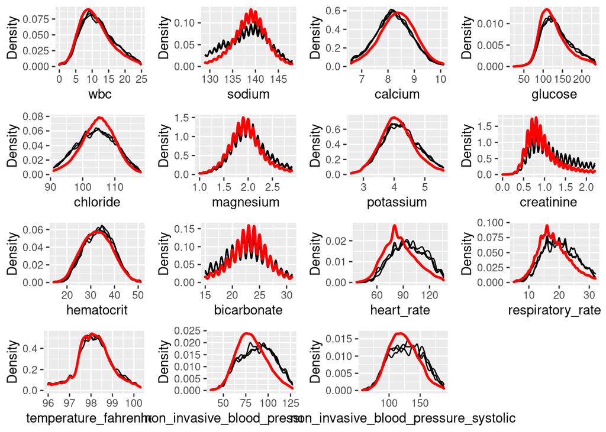

```r
# Load the data
mice_icu <- readRDS("mice.rds")
# Diagnostic Plots
plotDistributions(mice_icu, vars = 'allNumeric')
```

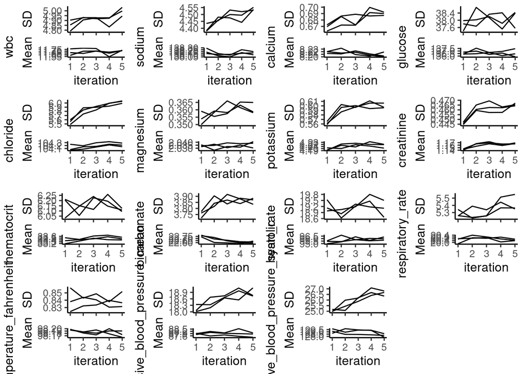

```r
plotVarConvergence(mice_icu, vars = 'allNumeric')
```

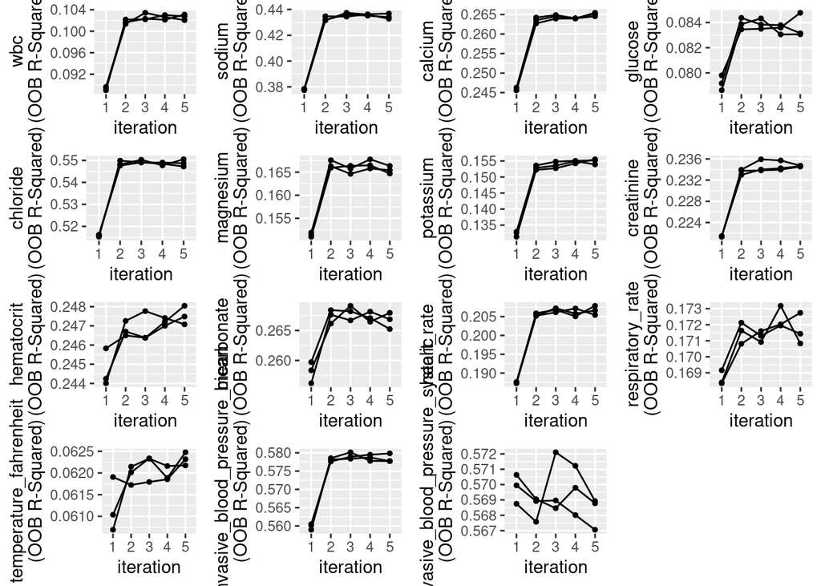

```r
plotModelError(mice_icu, vars = 'allNumeric')
```

- The first set of plots show original distributions (red) and imputed distributions (black). For most of the measurements, these distributions match fairly closely, but there are obvious deviations for heart rate, mean non-invasive blood pressure, non-invasive systolic blood pressure, and respiratory rate, suggesting that the data was not missing completely at random.
- The second set of plots show if the imputed data has converged over the five iterations ran. Most of the measurements have converged, but magnesium, glucose, respiration rate, temperature in Fahrenheit, and heart rate all show obvious divergence. Perhaps more iterations need to be run.
- The third set of plots show OOB accuracy/r-squared values. Since non of the plots reaches accuracy/r-squared above 0.6, it can be concluded that none of the variables were imputed with high accuracy. There is also obvious deviations in accuracy for non-invasive systolic blood pressure between the three imputed data sets.
6. Choose one of the imputed data sets to be used in Q2. This is **not** a good idea to use just one imputed data set or to average multiple imputed data sets. Explain in a couple of sentences what the correct Multiple Imputation strategy is.

## 1.6 Solution

```r
# Prep Data by creating dummy variables for categorical variables
list <- completeData(mice_icu)
final_data <- model.matrix(~ gender + admit_age + marital_status + ethnicity +
                          wbc + sodium + calcium + glucose + chloride +
                          magnesium + potassium + creatinine + hematocrit +
                          bicarbonate + heart_rate + respiratory_rate +
                          temperature_fahrenheit +
                          non_invasive_blood_pressure_mean +
                          non_invasive_blood_pressure_systolic +
                          thirty_day_mort, data = list[[1]])
```

- I will just choose the first imputed data set for Q2, but this is not the right imputation strategy. The correct multiple imputation strategy is to pool multiple imputed data sets to combine within-imputation variance (the variance for each individual imputed data set) and between-imputation variance (shifts between imputed data sets). This is done by combining the parameter estimates into one set of estimates. Under the correct conditions, this set of estimates are unbiased and have the appropriate statistical properties.

# 2 Q2. Predicting 30-day mortality

Develop at least two analytic approaches for predicting the 30-day mortality of patients admitted to ICU using demographic information (gender, age, marital status, ethnicity), first lab measurements during ICU stay, and first vital measurements during ICU stay. For example, you can use (1) logistic regression (`glm()` function in base R or keras), (2) logistic regression with lasso penalty (glmnet or keras package), (3) random forest (randomForest package), or (4) neural network (keras package).

1. Partition data into 80% training set and 20% test set. Stratify partitioning according the 30-day mortality status.

## 2.1 Solution

- I will use logistic regression and a neural network for this assignment.

```r
# Convert to data frame for partitioning
final_frame <- as.data.frame(final_data)
# Set the seed for reproducible results
set.seed(1234)
# Create partition
train_index <- createDataPartition(
  final_frame$thirty_day_mortYes,
  p = .8,
  list = FALSE
)
train <- final_frame[train_index, ]
test <- final_frame[-train_index, ]
```

2. Train the models using the training set.

## 2.2 Solution

```r
# Creating logistic regression model
regression <- glm(
  thirty_day_mortYes ~. -`(Intercept)`,
  data = train,
  family = binomial
)
summary(regression)
```

```
##
## Call:
## glm(formula = thirty_day_mortYes ~ . - `(Intercept)`, family = binomial,
##     data = train)
##
## Deviance Residuals:
##     Min       1Q   Median       3Q      Max
## -2.1740  -0.4592  -0.3237  -0.2264   3.4815
##
## Coefficients:
##                                        Estimate Std. Error z value Pr(>|z|)
## (Intercept)                          11.7062832  2.2684937   5.160 2.46e-07 ***
## genderM                              -0.1743633  0.0377774  -4.616 3.92e-06 ***
## admit_age                             0.0267232  0.0013005  20.548  < 2e-16 ***
## marital_statusMARRIED                -0.0640671  0.0680402  -0.942  0.34639
## marital_statusSINGLE                 -0.0083101  0.0720816  -0.115  0.90822
## marital_statusWIDOWED                -0.0366481  0.0771146  -0.475  0.63461
## ethnicityASIAN                        0.3649133  0.4206662   0.867  0.38569
## `ethnicityBLACK/AFRICAN AMERICAN`    -0.1080543  0.4144764  -0.261  0.79432
## `ethnicityHISPANIC/LATINO`           -0.0996649  0.4251525  -0.234  0.81466
## ethnicityOTHER                        0.1665764  0.4181370   0.398  0.69035
## `ethnicityUNABLE TO OBTAIN`           0.9867015  0.4275944   2.308  0.02102 *
## ethnicityUNKNOWN                      1.0125397  0.4117738   2.459  0.01393 *
## ethnicityWHITE                        0.0693095  0.4102985   0.169  0.86586
## wbc                                   0.0251268  0.0035316   7.115 1.12e-12 ***
## sodium                                0.0774450  0.0061558  12.581  < 2e-16 ***
## calcium                              -0.2522102  0.0285298  -8.840  < 2e-16 ***
## glucose                               0.0027224  0.0004585   5.938 2.89e-09 ***
## chloride                             -0.0885615  0.0046803 -18.922  < 2e-16 ***
## magnesium                             0.1438652  0.0516829   2.784  0.00538 **
## potassium                            -0.0147298  0.0313228  -0.470  0.63817
## creatinine                            0.8346205  0.0429455  19.434  < 2e-16 ***
## hematocrit                           -0.0023132  0.0029216  -0.792  0.42850
## bicarbonate                          -0.1128758  0.0057906 -19.493  < 2e-16 ***
## heart_rate                            0.0109504  0.0010099  10.843  < 2e-16 ***
## respiratory_rate                      0.0463767  0.0035007  13.248  < 2e-16 ***
## temperature_fahrenheit               -0.1565201  0.0217548  -7.195 6.26e-13 ***
## non_invasive_blood_pressure_mean      0.0023280  0.0015875   1.466  0.14252
## non_invasive_blood_pressure_systolic -0.0084903  0.0011198  -7.582 3.40e-14 ***
## ---
## Signif. codes:  0 '***' 0.001 '**' 0.01 '*' 0.05 '.' 0.1 ' ' 1
##
## (Dispersion parameter for binomial family taken to be 1)
##
##     Null deviance: 27893  on 42451  degrees of freedom
## Residual deviance: 23667  on 42424  degrees of freedom
## AIC: 23723
##
## Number of Fisher Scoring iterations: 6
```

```r
# Predict for test set
predicted <- predict(regression, test, type = "response")
# Set prediction threshold to 0.5
final_predict <- ifelse(predicted > 0.5, "Yes", "No")
# Create and print confusion matrix
confusion_matrix <- table(test$thirty_day_mortYes, final_predict)
confusion_matrix
```

```
##    final_predict
##       No  Yes
##   0 9418   72
##   1 1026   97
```

```r
# Create neural network
# Convert training and testing data sets to matrix
neural_train <- as.matrix(train)
neural_test <- as.matrix(test)
# Split independent variables and dependent outcome (30 day mortality)
x_train <- neural_train[, 2:28]
x_test <- neural_test[, 2:28]
y_train <- neural_train[, 29]
y_test <- neural_test[, 29]
# Create model
library(keras)
# install_keras(tensorflow = 2.6)
model <- keras_model_sequential()
```

```
## Loaded Tensorflow version 2.6.2
```

```r
model %>%
  layer_dense(units = 128, activation = 'relu', input_shape = c(27)) %>%
  layer_dropout(rate = 0.5) %>%
  layer_dense(units = 64, activation = 'relu') %>%
  layer_dropout(rate = 0.5) %>%
  layer_dense(units = 1, activation = 'sigmoid')
summary(model)
```

```
## Model: "sequential"
## ________________________________________________________________________________
## Layer (type)                        Output Shape                    Param #
## ================================================================================
## dense_2 (Dense)                     (None, 128)                     3584
## ________________________________________________________________________________
## dropout_1 (Dropout)                 (None, 128)                     0
## ________________________________________________________________________________
## dense_1 (Dense)                     (None, 64)                      8256
## ________________________________________________________________________________
## dropout (Dropout)                   (None, 64)                      0
## ________________________________________________________________________________
## dense (Dense)                       (None, 1)                       65
## ================================================================================
## Total params: 11,905
## Trainable params: 11,905
## Non-trainable params: 0
## ________________________________________________________________________________
```

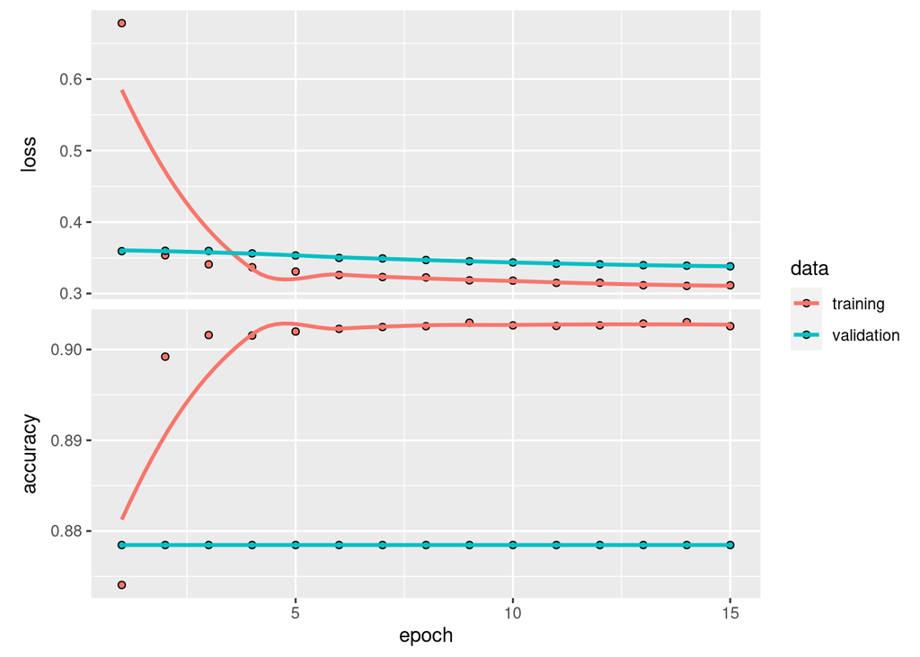

```r
# Compile the model
model %>%
  compile(
    loss = 'binary_crossentropy',
    optimizer = optimizer_adagrad(),
    metrics = 'accuracy'
  )

# Train the model
visuals <- model %>%
  fit(
    x_train, y_train,
    epochs = 15, batch_size = 32,
    #class_weight = list ("0" = 1, "1" = 6),
    validation_split = 0.2
  )
plot(visuals)
```

3. Compare model prediction performance on the test set.

## 2.3 Solution

```r
# Accuracy for logistic regression
accuracy <- sum(diag(confusion_matrix)) / sum(confusion_matrix)
accuracy
```

```
## [1] 0.896542
```

```r
# Accuracy for neural network
model %>%
  evaluate(x_test, y_test)
```

```
##      loss  accuracy
## 0.3130889 0.8941864
```

- Accuracy for both methods was between 0.89 and 0.90. I tried to assign class weights due to imbalanced data since only about 10% of patients died within 30 days of hospital admission, but this messed up my neural network.